# Final Project

Jesse Quijano

2024-12-07

# What Continent has the most meteorite strikes by quantity and volume?

This question came about while reading the book The Asteroid Hunter by Daunte S. Lauretta. In the book the author says that 19 meteorites strike the earth daily and it got me to wondering… Where are they hitting? While reviewing the data, I also became interested in how large the meteorites are. Here is my analysis.

```r
rm(list = ls())
library(tidyverse)
library(rworldmap)
#install.packages("rworldmap")
#install.packages("maps")
```

## The Data Sets

Three primary data sets were used:

### NASA Data

The primary data set I will use is from The National Aeronautics and Space Administration (NASA).

Each case, 45,716 in total, represents a meteorite that has “landed” on Earth. There are 7,315 cases with NA for their latitude/longitude coordinates, which are removed for this analysis. The majority of these were actually found in various Antarctica regions based on some preliminary research of the meteorite names. Augmenting the results with research about latitude and longitude information to include these data, might impact the outcomes.

```r
data <- read.csv("Meteorite_Landings_20241109.csv")
head(data)
```

|  | name | id | nametype | recclass | mass..g. | fall | year | reclat | reclong | GeoLocation |
| --- | --- | --- | --- | --- | --- | --- | --- | --- | --- | --- |
| 1 | Aachen | 1 | Valid | L5 | 21 | Fell | 1880 | 50.77500 | 6.08333 | (50.775, 6.08333) |
| 2 | Aarhus | 2 | Valid | H6 | 720 | Fell | 1951 | 56.18333 | 10.23333 | (56.18333, 10.23333) |
| 3 | Abee | 6 | Valid | EH4 | 107000 | Fell | 1952 | 54.21667 | -113.00000 | (54.21667, -113.0) |
| 4 | Acapulco | 10 | Valid | Acapulcoite | 1914 | Fell | 1976 | 16.88333 | -99.90000 | (16.88333, -99.9) |
| 5 | Achiras | 370 | Valid | L6 | 780 | Fell | 1902 | -33.16667 | -64.95000 | (-33.16667, -64.95) |
| 6 | Adhi Kot | 379 | Valid | EH4 | 4239 | Fell | 1919 | 32.10000 | 71.80000 | (32.1, 71.8) |

!! More information on the NASA data can be found at [NASA: Meteorite Landings](https://data.nasa.gov/Space-Science/Meteorite-Landings/gh4g-9sfh/about_data)

### Spatial Polygon Data

We’ll use this data from the rworldxtra CRAN package to determine which continent lat/long coordinates belong to.

```r
library(sp)
#install.packages("rworldxtra")
library(rworldxtra)

countriesSP <- getMap(resolution='high')
head(countriesSP)
```

```
class       : SpatialPolygonsDataFrame
features    : 6
extent      : -70.06164, 74.89231, -18.0314, 60.48075  (xmin, xmax, ymin, ymax)
crs         :  +proj=longlat +ellps=WGS84 +datum=WGS84 +no_defs +towgs84=0,0,0
variables   : 51
names       : ne_10m_adm, ScaleRank, LabelRank,    FeatureCla, OID_,     SOVEREIGNT, SOV_A3, ADM0_DIF, LEVEL,              TYPE,       ADMIN, ADM0_A3, GEOU_DIF,     GEOUNIT, GU_A3, ...
min values  :        ABW,         1,         2, Adm-0 country,   16,    Afghanistan,    AFG,        0,     2,           Country, Afghanistan,     ABW,        0, Afghanistan,   ABW, ...
max values  :        ALD,         3,         8, Adm-0 country,   82, United Kingdom,    NL1,        1,     2, Sovereign country,       Aruba,     ALD,        0,       Aruba,   ALD, ...
```

!! More information on the [rworldxtra package](https://cran.r-project.org/web/packages/rworldxtra/index.html)

## ggplot Maps

```r
world <- map_data("world") #from ggplot2
head(world)
```

|  | long | lat | group | order | region | subregion |
| --- | --- | --- | --- | --- | --- | --- |
| 1 | -69.89912 | 12.45200 | 1 | 1 | Aruba | NA |
| 2 | -69.89571 | 12.42300 | 1 | 2 | Aruba | NA |
| 3 | -69.94219 | 12.43853 | 1 | 3 | Aruba | NA |
| 4 | -70.00415 | 12.50049 | 1 | 4 | Aruba | NA |
| 5 | -70.06612 | 12.54697 | 1 | 5 | Aruba | NA |
| 6 | -70.05088 | 12.59707 | 1 | 6 | Aruba | NA |

## Setup Functions

Because we are dealing with spatial data, a direct join (left/full/inner, etc.) was not possible. This function joins the primary data with the spacial data.

```r
coords_to_continent = function(points) {
  pointsSP = SpatialPoints(points, proj4string=CRS(proj4string(countriesSP)))
  indices = over(pointsSP, countriesSP)
  indices$REGION # will for sure need this!
}
```

## Plot the general landing data on the world map

Before digging into answering the actual question posed, I plotted the raw data on the world map to provide a visual representation to base my hypothesis on. At a glance, I thought North America would be the continent that had the most meteorite finds. I reasoned that we would have more sightings in NASA data given that it is a North American organization.

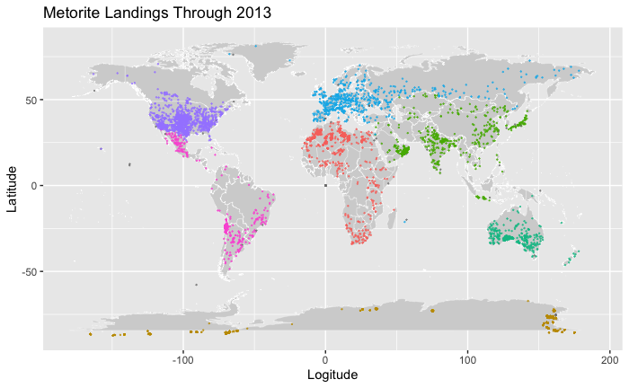

```r
prepared_data <- data %>%
  filter(!is.na(reclong), reclong <= 180, reclong >= -180) %>% # remove the outliers - even NASA data has some bugs!
  mutate(continent = coords_to_continent(data.frame(longitude = c(reclong), latitude = c(reclat)))) %>%
  select(lat = reclat, long = reclong, continent, weight = mass..g.)

world %>% ggplot(aes(x = long, y = lat, colour = continent)) +
  geom_map(
    map = world,
    aes(map_id = region),
    color = "white",
    fill = "lightgray",
    linewidth = 0.1
  ) +
  geom_point(
    data = prepared_data,
    aes(x = long, y = lat),
    alpha = 0.7,
    size = .1
  ) +
  guides(fill="none", color="none") +
  ylab("Latitude") +
  xlab("Logitude") +
  ggtitle("Metorite Landings Through 2013")
```

## First we look at the total number of meteorite strikes by Continent.

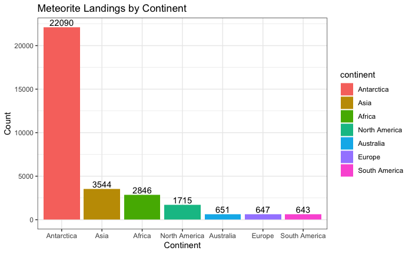

```r
# prepare the count data: clean up SA, sum, and order
count_ready <- prepared_data %>%
  mutate(continent = str_replace(continent, ".*South.*", "South America")) %>%
  filter(!is.na(continent)) %>%
  group_by(continent) %>%
  summarise(count = n()) %>%
  arrange(desc(count)) %>%
  mutate(continent = factor(continent, levels = unique(continent))) # only way I could find to set the order of the chart

# plot the bar chart with labels, ordered by count
count_ready %>%
  ggplot(aes(x = continent, y = count, fill = continent)) +
  geom_col(position = 'dodge') +
  geom_text(aes(label=count), position=position_dodge(width=0.9), vjust=-0.25) +
  scale_fill_hue(direction = 1) +
  theme_bw() +
  xlab("Continent") +
  ylab("Count") +
  ggtitle("Meteorite Landings by Continent")
```

The winner, by a landslide, is Antarctica with 6+ times the number of landings over its nearest competition.

## Now let’s do a similar analysis by weight/mass (in KG).

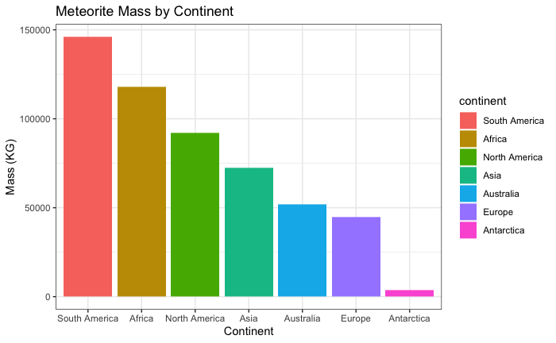

```r
# prepare the count data: clean up SA, sum, and order
weight_ready <- prepared_data %>%
  mutate(continent = str_replace(continent, ".*South.*", "South America")) %>%
  filter(!is.na(continent), !is.na(weight)) %>%
  group_by(continent) %>%
  summarise(total_mass = sum(weight) / 1000) %>%
  arrange(desc(total_mass)) %>%
  mutate(continent = factor(continent, levels = unique(continent))) # only way I could find to set the order of the chart

ggplot(weight_ready) +
  aes(x = continent, y = total_mass, fill = continent) +
  geom_col() +
  scale_fill_hue(direction = 1) +
  theme_bw() +
  xlab("Continent") +
  ylab("Mass (KG)") +
  ggtitle("Meteorite Mass by Continent")
```

I expected that Antarctica would have contained the most meteorite material given it’s overwhelming lead in count. Instead it was the smallest by weight and South America was actually the holder of the most meteorite material! So, it turns out that number and volume are not related as I initially expected.

## Challenges

The biggest issue I faced building out these visualization is the underlying NASA data only contains lat/long coordinates - which I did not know before selecting this topic for research. This could be easily plotted on a map, but that was not my guiding question. It was regarding continents. I therefore had to find a way to convert that data. Not surprisingly, I could not find a data set I could just “left join” (or right, or any other standard join) to the NASA data. Lots of Googling and experimenting later, I ran across a Stack Overflow article that outlined a way to turn vectors of latitudes and vectors of longitudes into map data - country, continent, etc. But this still wasn’t a fit because I did not want to have to create a dataframe that had EVERY set of coordinates in the NASA data, convert that to a continent, then join it back to the primary data. So I came up with the idea to just mutate a new column using a function:

`mutate(continent = coords_to_continent(data.frame(longitude = c(reclong), latitude = c(reclat))))`

It still takes a bit of time to do the look-up (about 5-6 seconds), but it’s faster and WAY more efficient than a standard join. Especially given that I mutate it once, take the performance hit, then reuse the data and it’s very fast.

The other issue I ran into was trying to convert “South America and the Caribbean” to “South America” - which fits on my axes much nicer. I initially tried using `ifelse(grepl("^South", continent, ignore.case = TRUE), "South America", continent)` It would have been a perfect solution because it uses control flow AND RegEx, but it would find and do the variable replacement for South America properly, but for all of the other values rather than using the value as expected, it would give me a number. Some type of enumeration that I never could figure out how to get to show the value. I ended up using `str_replace()` instead.